# Noworodki pozostawione w szpitalu nie ze względów zdrowotnych

Yahor Lahunovich

2024-12-07

# Wstęp

Projekt zrealizowano w ramach inicjatywy #BI_NGO Fundacji Gajusz.

Przeglądając dane udostępnione przez fundację, zdecydowałem się skupić na temacie noworodków pozostawionych w szpitalu nie ze względów zdrowotnych w Polsce w latach 2007-2023.

# Ogólny trend w Polsce

Na początek, przyjrzałem się ogólnemu trendowi tej problematyki w całej Polsce. Chciałem sprawdzić, jaki procent wszystkich noworodków zostaje w szpitalu z powodów innych niż zdrowotne.

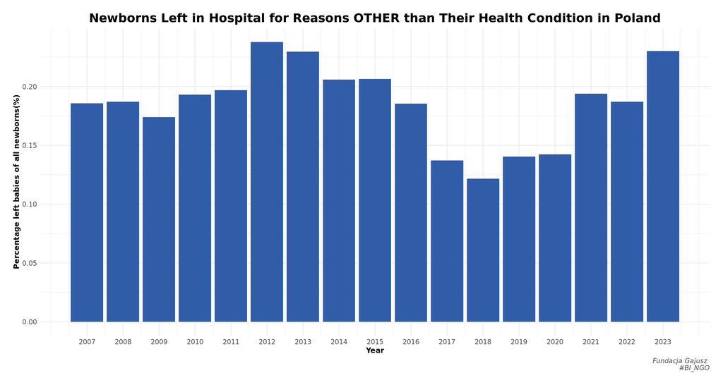

Na powyższym wykresie można zauważyć, że poziom pozostawiania noworodków w szpitalach na przestrzeni lat utrzymywał się na podobnym poziomie. W latach 2017-2020 zaobserwowano jednak znaczący spadek. Ciekawe, czy istnieją konkretne przyczyny tego spadku? A może problemem są dane?

# Województwa

Następnie przyjrzałem się, w których województwach pozostawia się najwięcej noworodków. W tym celu wybrałem lata 2007, 2015 i 2023, by zobaczyć zmiany na przestrzeni czasu.

[figure not shown]

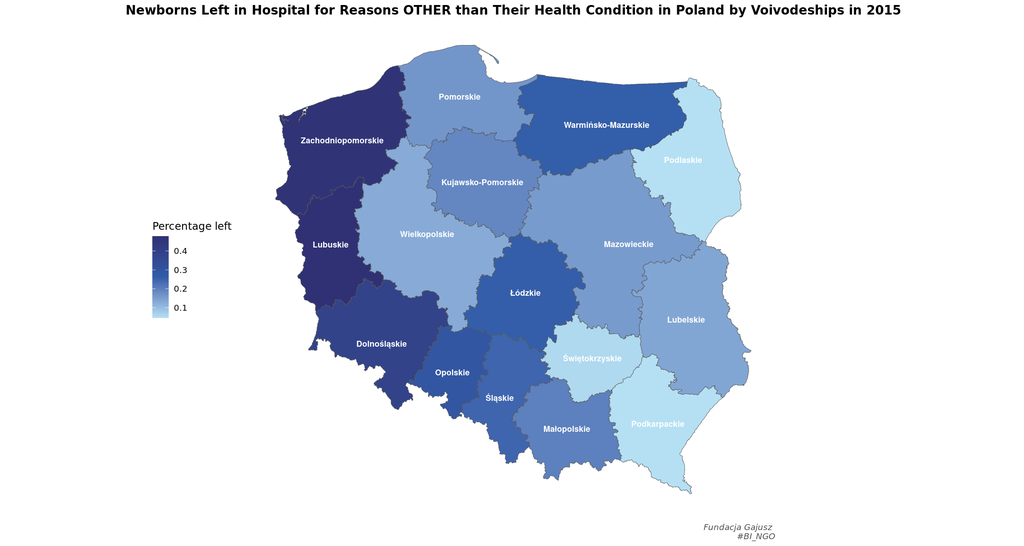

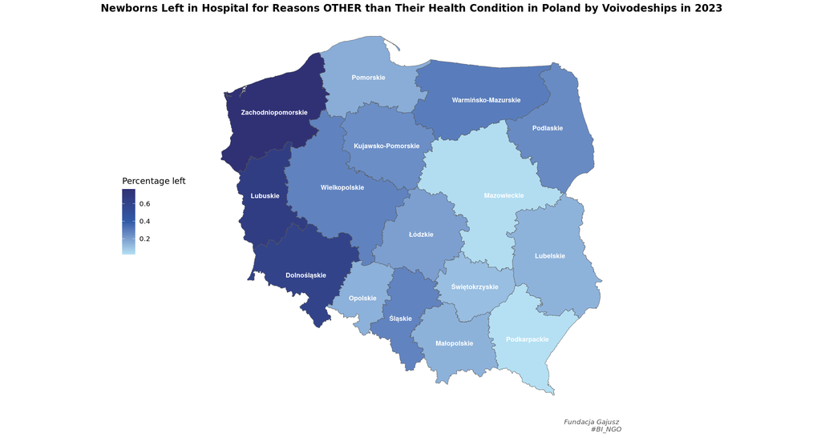

Porównując te mapy, można zauważyć, że problem częściej występuje w województwach zachodnich Polski. Dlaczego tak jest? Warto zgłębić tę kwestię.

# Wykres porównawczy

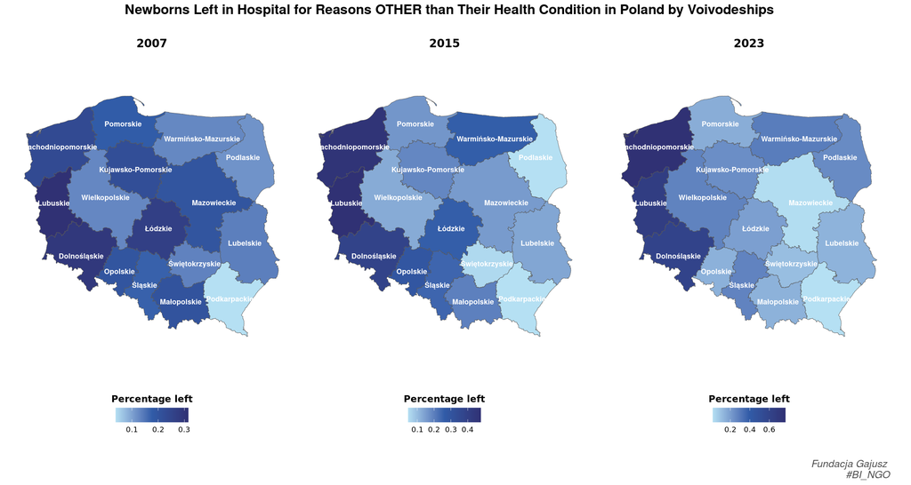

# Trendy w województwach

Na koniec zastosowałem metody regresji liniowej do danych, aby sprawdzić, w których województwach sytuacja się poprawia, a w których pogarsza.

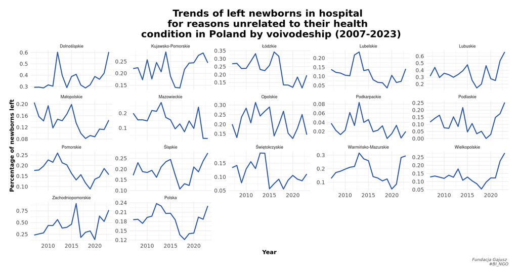

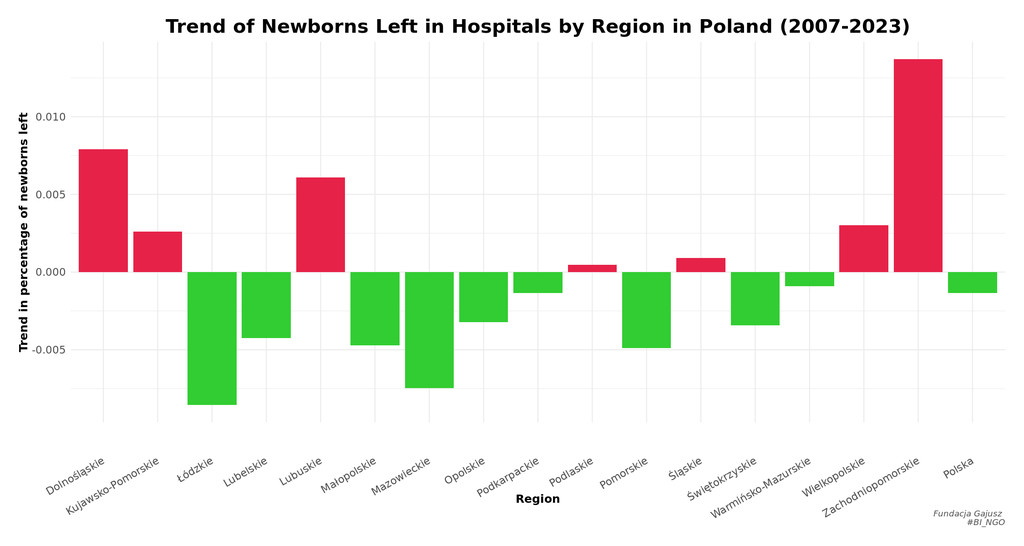

Widać, że w większości województw sytuacja ulega poprawie, ale są regiony, w których problem się nasila.

# Podsumowanie

Mam nadzieję, że przygotowane przeze mnie wizualizacje pomogą w zobrazowaniu istniejącego problemu. Interesujące byłoby również przeanalizowanie podobnych danych w innych krajach europejskich w celu porównania.